# Travaux dirigés 2 - MAP201, thème équation différentielles

Le TP est à faire en python, où la réponse à chaque question est dans une cellule séparée. On veillera à écrire un code suffisamment clair pour être éventuellement réutilisé d'un exercice à l'autre.

```python
import numpy as np #importe les outils de gestion des tableaux
import matplotlib.pyplot as plt #importe les outils d'affichages matplotlib
plt.rcParams['figure.dpi'] = 120 #reglage facultatif de résolution des figures
plt.rcParams['savefig.dpi'] = 240 #reglage facultatif de résolution des figures enregistrées
```

## Exercice 1 - Etude de x'=sin(x)

Soit $x:\R\to\R$ une solution de l'équation $\dot{x}(t)=\sin(x(t))$, avec $x(0)\in ]0,\pi[$.

### 1)

Quelle est le sens de variation et la limite de $x(t)$ en $t\to +\infty$, en $t\to -\infty$ ?

Réponse: comme 0<x(0)<pi alors sin(x)>0 donc elle est croissante

### 2)

Pour quelle valeur de $x(t)$ la vitesse $\dot{x}(t)$ est-elle maximale ?

Réponse: x(t) est maximale lorsque sin(x) = 1 donc x=pi/2

### 3)

Donner une expression de $\ddot{x}(t)$ en fonction de la valeur $x(t)$. Pour quelle valeur de $x(t)$ l'accélération $\ddot{x}(t)$ est-elle maximale ?

Réponse: x''(t) = x'(t) cos(x(t)) = sin(x(t)) cos(x(t))

l'accéleration (x''(t)) est maximale: x''(t)=pi/4

## Exercice 2 - Etude du pendule.

On considère un pendule de longueur $\ell=1$ (mètre), $x(t)$ représente l'angle formé entre la tige du pendule et la verticale à l'instant $t$ ($x=0$ correspond à la position au repos). Le pendule est laché au temps $t=0$ à un angle $x_0\in \R$, à vitesse nulle. L'évolution de $t\mapsto x(t)$ est donnée par l'équation

$$ \begin{cases} \ddot{x}(t)=-\frac{g}{\ell}\sin(x(t))\\ x(0)=x_0, \dot{x}(0)=0 \end{cases}$$

où $g=9.81 m.s^{-2}$ est l'intensité de la pesanteur.

### 1)

Réécrire l'équation différentielle d'ordre $2$ vérifiée par $x(t)$ comme un système différentielle de la forme $\begin{cases}\dot{x}(t)=f(t,x(t),y(t))\\ \dot{y}(t)=g(t,x(t),y(t))\end{cases}$.

Réponse: en notant y = x' , cela est équivalent à la résolution de x'(t) = y(t) y'(t) = (-g/l) sin(x(t)) x(0)=x0 y(0)=0

### 2)

Ecrire une fonction qui prend en entrée une condition initiale $x_0\in \R$, un temps final $T_{fin}>0$, un nombre de pas $N\in\mathbb{N}$, et renvoie trois tableaux $T=[t_0,...,t_N],X=[x_0,..,x_N],Y=[y_0,..,y_N]$, tel que $t_i=iT/N$ et $(x_i,y_i)$ est l'approximation de $(x(t_i),y(t_i))$ au temps $t_i$ obtenue par méthode d'Euler appliquée à l'équation de $x(t),y(t)$.

```python
#Réponse:
import numpy as np
import matplotlib.pyplot as plt

g = 9.81  # constante gravitationnelle
l = 1.0   # longueur du pendule

def euler_pendulum(x0, Tfin, N):
    t = np.linspace(0, Tfin, N+1)
    dt = Tfin / N

    x = np.zeros(N+1)
    y = np.zeros(N+1)

    # Conditions initiales
    x[0] = x0
    y[0] = 0

    # Méthode d'Euler
    for i in range(N):
        x[i+1] = x[i] + dt * y[i]
        y[i+1] = y[i] + dt * (-g/l) * np.sin(x[i])

    return t, x, y
```

### 3)

On fixe un temps final $T=5$. Afficher les solutions obtenues pour les conditions initiales $x_0\in \{-6,-5,-4,...,5,6\}$, avec un nombre de pas suffisament grand.

On affichera dans une première fenètre les graphes de $x(t)$ en fonction de $t$, et dans une seconde fenêtre les tracés des courbes $\{(x(t),y(t)), t\in [0,T]\}$.

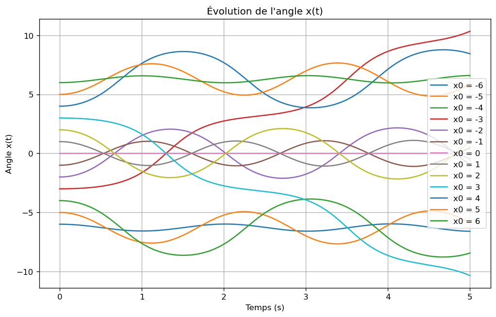

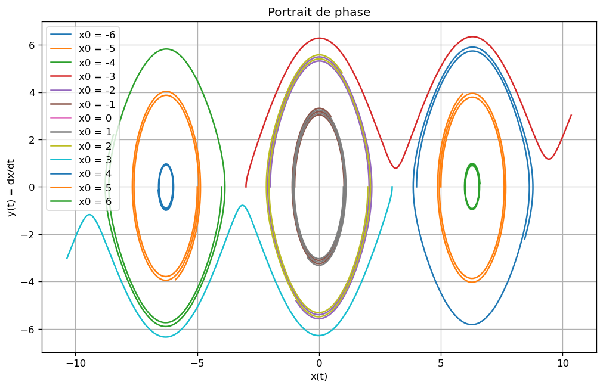

```python
#Réponse:
T = 5
N = 1000  # Nombre de pas suffisamment grand
x0_values = np.arange(-6, 7, 1)

# Première figure : x(t) en fonction de t
plt.figure(figsize=(10, 6))
for x0 in x0_values:
    t, x, y = euler_pendulum(x0, T, N)
    plt.plot(t, x, label=f'x0 = {x0}')
plt.xlabel('Temps (s)')
plt.ylabel('Angle x(t)')
plt.grid(True)
plt.legend()
plt.title('Évolution de l\'angle x(t)')
plt.show()

# Deuxième figure : portrait de phase (x,y)
plt.figure(figsize=(10, 6))
for x0 in x0_values:
    t, x, y = euler_pendulum(x0, T, N)
    plt.plot(x, y, label=f'x0 = {x0}')
plt.xlabel('x(t)')
plt.ylabel('y(t) = dx/dt')
plt.grid(True)
plt.legend()
plt.title('Portrait de phase')
plt.show()
```

### 4)

On admet le résultat suivant: lorsque $x(0)\in ]0,\pi[$, $\dot{x}(0)=0$, alors la période de $t\mapsto x(t)$ est la plus petite valeur pour laquelle $\dot{x}(t)$ passe de positif à négatif. Ecrire une fonction prenant en entrée un nombre $x_0>0$, qui calcule la période $P(x_0)$ de la solution associée à la condition initiale $x(0)=x_0,\dot{x}(0)=0$.

```python
#Réponse:
def calculate_period(x0, Tmax=20, N=10000):
    t, x, y = euler_pendulum(x0, Tmax, N)
    dt = Tmax / N

    # Trouver le premier passage de y de positif à négatif
    for i in range(1, N):
        if y[i-1] > 0 and y[i] <= 0:
            # Interpolation linéaire pour plus de précision
            t_cross = t[i-1] + dt * y[i-1] / (y[i-1] - y[i])
            return t_cross
    return None  # Si pas de période trouvée
```

## 5)

Afficher le graphe de $P(x_0)$ en fonction de $x_0$, pour $x_0$ parcourant une subdivision suffisament fine de l'intervalle $]0,\pi/2]$. On pourra tracer sur la même figure la formule asymptotique $$P_{asymptotic}(x_0)=2\pi\sqrt{\frac{\ell}{g}}\left(1+\frac{x_0^2}{16}\right)$$ et comparer les deux.

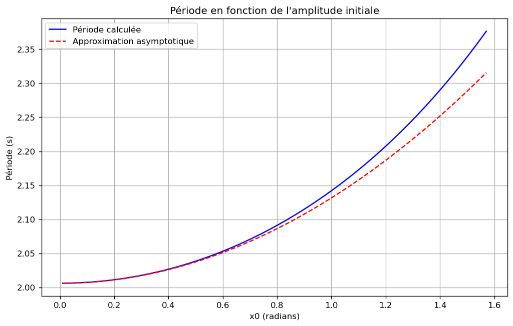

```python
#Réponse:
x0_range = np.linspace(0.01, np.pi/2, 50)
periods = [calculate_period(x0) for x0 in x0_range]

# Formule asymptotique
P_asymptotic = lambda x0: 2 * np.pi * np.sqrt(l/g) * (1 + x0**2/16)
periods_asym = [P_asymptotic(x0) for x0 in x0_range]

plt.figure(figsize=(10, 6))
plt.plot(x0_range, periods, 'b-', label='Période calculée')
plt.plot(x0_range, periods_asym, 'r--', label='Approximation asymptotique')
plt.xlabel('x0 (radians)')
plt.ylabel('Période (s)')
plt.grid(True)
plt.legend()
plt.title('Période en fonction de l\'amplitude initiale')
plt.show()
```

## Exercice 3 - Modèle d'épidémie.

On considère une population de $S$ individus sains où l'on introduit à l'instant $t=0$, une population de $m$ individus malades. On suit ensuite l'évolution de l'épidémie en divisant la population en trois parties distinctes:

- $x(t)$: la population d'individus sains, qui vérifie $x(0)=S(>0)$.
- $y(t)$: la population d'individus malades, qui vérifie $y(0)=m(>0)$.
- $z(t)$: la population d'individus qui sont guéris et immunisés de la maladie. A l'instant $t=0$ on a $z(0)=0$.

On suppose que $x(t),y(t),z(t)$ suivent une évolution du type $$\begin{cases} \dot{x}(t)=-k\frac{y(t)}{x(t)+y(t)+z(t)}x(t) & (1)\\ \dot{y}(t)=k\frac{y(t)}{x(t)+y(t)+z(t)}x(t)-\ell y(t) & (2)\\ \dot{z}(t)= \ell y(t) & (3) \end{cases}$$ où $k,\ell>0$ sont des paramètres de la maladie.

### 1)

Donner une interprétation de chaque terme du modèle. Que peuvent représenter les quantités $k,\ell $ ?

Réponse:

# Interprétation du modèle d'épidémie

Le système d'équations différentielles décrit la dynamique d'une épidémie dans une population divisée en individus susceptibles ((x(t))), infectés ((y(t))) et rétablis ((z(t))). La population totale est constante : (x(t) + y(t) + z(t) = S + m), car (x(0) = S), (y(0) = m) et (z(0) = 0). Décomposons chaque équation :

- **Équation (1) :
  - Cette équation représente le taux auquel les individus susceptibles deviennent infectés.
  - Le terme ( \frac{y(t)}{x(t) + y(t) + z(t)} ) est la proportion d'individus infectés dans la population totale, reflétant la probabilité qu'un susceptible rencontre un infecté.
  - Multiplier par ( x(t) ) donne le nombre de nouvelles infections, qui dépend à la fois du nombre de susceptibles et du risque d'infection.
  - Le signe négatif indique une perte d'individus susceptibles.
  - ( k ) est le taux d'infection, mesurant la rapidité de propagation de la maladie par unité de contact.
- **Équation (2) :
  - Cette équation suit l'évolution de la population infectée.
  - Le premier terme, ( k \frac{y(t)}{x(t) + y(t) + z(t)} x(t) ), représente l'arrivée de nouvelles infections (identique à la perte de ( x(t) )).
  - Le second terme, ( -\ell y(t) ), est le taux auquel les infectés guérissent, réduisant ainsi la population infectée.
  - ( \ell ) est le taux de guérison, indiquant la vitesse à laquelle les infectés se rétablissent et deviennent immunisés.
- **Équation (3) :
  - Cette équation donne le taux d'augmentation des individus rétablis.
  - Il est égal au terme de guérison de ( y(t) ), car tous les individus qui guérissent passent dans la classe des rétablis.
  - L'absence d'un terme de perte reflète une immunité permanente dans ce modèle.

**Paramètres :**

- ( k ) : Taux d'infection (par exemple, par jour), lié à la contagiosité et à la fréquence des contacts.
- ( \ell ) : Taux de guérison (par exemple, par jour), inversement proportionnel à la durée moyenne de la maladie (durée ≈ ( 1/\ell )).

### 2)

Grâce à une méthode d'Euler, calculer les solutions et tracer le graphe de $x(t),y(t),z(t)$ en fonction de $t$, pour les paramètres suivants:

$$S=100, m=1,k=5, \ell=3$$

On utilisera un nombre de pas $N$ suffisamment grand. On pensera a bien annoter chaque courbe, et à afficher le graphe sur un temps suffisamment grand pour observer toute l'évolution de $x,y,z$. Par lecture graphique, quel est le sens de variation et le comportement asymptotique de $x(t),y(t),z(t)$ ? On pourra aussi calculer leur valeur limites et extrémales.

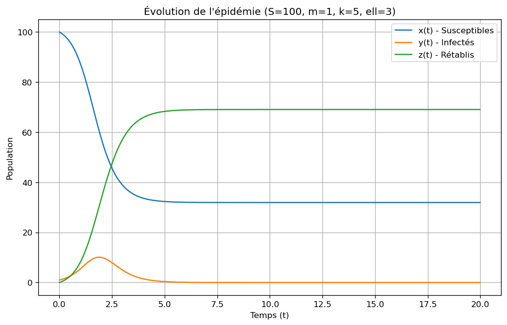

```python
#Réponse:
def derivatives(x, y, z, k, ell):
    total = x + y + z
    dx_dt = -k * (y / total) * x
    dy_dt = k * (y / total) * x - ell * y
    dz_dt = ell * y
    return dx_dt, dy_dt, dz_dt

# Méthode d'Euler
def euler_method(S, m, k, ell, h=0.01, N=2000):
    t = np.arange(0, N * h, h)
    x = np.zeros(N)
    y = np.zeros(N)
    z = np.zeros(N)
    x[0], y[0], z[0] = S, m, 0

    for n in range(N - 1):
        dx_dt, dy_dt, dz_dt = derivatives(x[n], y[n], z[n], k, ell)
        x[n + 1] = x[n] + h * dx_dt
        y[n + 1] = y[n] + h * dy_dt
        z[n + 1] = z[n] + h * dz_dt

    return t, x, y, z

# Paramètres
S, m, k, ell = 100, 1, 5, 3
t, x, y, z = euler_method(S, m, k, ell)

# Tracé
plt.figure(figsize=(10, 6))
plt.plot(t, x, label='x(t) - Susceptibles')
plt.plot(t, y, label='y(t) - Infectés')
plt.plot(t, z, label='z(t) - Rétablis')
plt.xlabel('Temps (t)')
plt.ylabel('Population')
plt.title('Évolution de l\'épidémie (S=100, m=1, k=5, ell=3)')
plt.legend()
plt.grid(True)
plt.show()
```

### 3)

Quels changements observe-t-on si on change $m=1$ en $m=0.1$, $m=0.01$ ? Comment change le tableau de variations des solutions ?

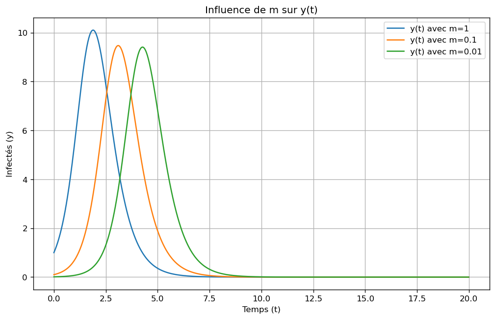

```
m=0.1:
Limite de x(t) : 32.26
Maximum de y(t) : 9.47 à t ≈ 3.10
Limite de z(t) : 67.84

m=0.01:
Limite de x(t) : 32.30
Maximum de y(t) : 9.41 à t ≈ 4.27
Limite de z(t) : 67.71
```

```python
#Réponse:
plt.figure(figsize=(10, 6))
for m in [1, 0.1, 0.01]:
    t, x, y, z = euler_method(S, m, k, ell)
    plt.plot(t, y, label=f'y(t) avec m={m}')
plt.xlabel('Temps (t)')
plt.ylabel('Infectés (y)')
plt.title('Influence de m sur y(t)')
plt.legend()
plt.grid(True)
plt.show()

# Analyse pour chaque m
for m in [0.1, 0.01]:
    t, x, y, z = euler_method(S, m, k, ell)
    print(f"\nm={m}:")
    print(f"Limite de x(t) : {x[-1]:.2f}")
    print(f"Maximum de y(t) : {max(y):.2f} à t ≈ {t[np.argmax(y)]:.2f}")
    print(f"Limite de z(t) : {z[-1]:.2f}")
```

### 4)

On étudie maintenant le changement de comportement de la maladie selon les paramètres $k,\ell$. On fixe $$S=100,m=0.1,\ell=4$$ et on va faire varier $k$ sur une subdivision de l'intervalle $[0,10]$. On note $z_{lim}(k)$ la limite de $z(t)$, lorsque $x(t),y(t),z(t)$ est la solution associée au paramètre $k$.

Ecrire une fonction qui renvoie une approximation de $z_{lim}(k)$, et afficher le graphe de $z_{lim}(k)$ en fonction de $k$ pour $k\in [0,10]$. Que constate-t-on ?

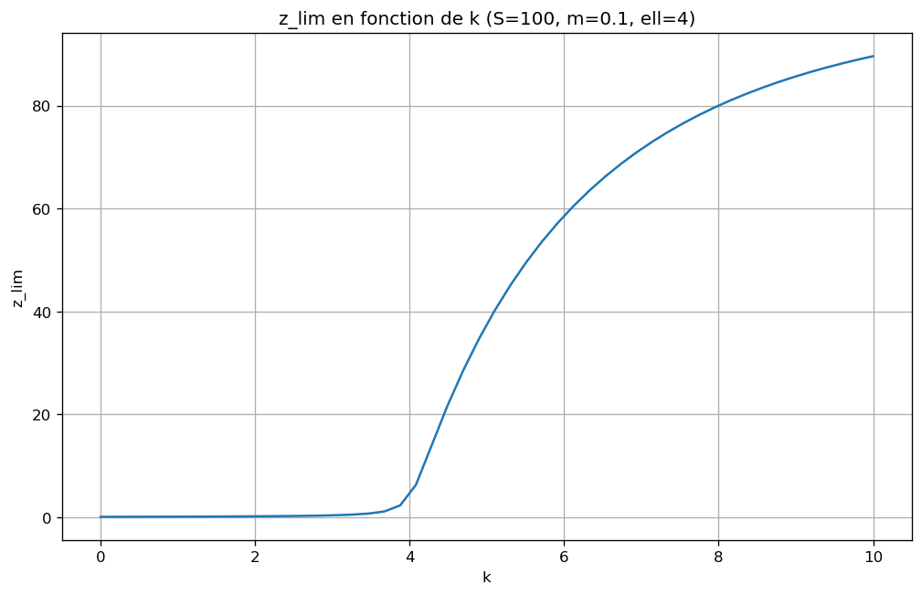

```python
#Réponse:
S, m, ell = 100, 0.1, 4
k_values = np.linspace(0, 10, 50)
z_lim = []

for k in k_values:
    t, x, y, z = euler_method(S, m, k, ell)
    z_lim.append(z[-1])

plt.figure(figsize=(10, 6))
plt.plot(k_values, z_lim, label='z_lim(k)')
plt.xlabel('k')
plt.ylabel('z_lim')
plt.title('z_lim en fonction de k (S=100, m=0.1, ell=4)')
plt.grid(True)
plt.show()
```

### 5) (Question ouverte)

Proposer une modification du modèle pour rendre compte d'un mécanisme supplémentaire: les individus guéris et immunisés perdent progressivement leur immunité. La durée d'immunité est supposée typiquement plus longue que la durée de la maladie elle-même.

On pourra représenter l'effet de cette modification du modèle.

Réponse: